*Note: These are rough notes for the Math 1113 Precalculus course at the University of Georgia*

# Precalculus

University of Georgia, Spring 2021

D. Zack Garza

University of Georgia  
dzackgarza@gmail.com

Last updated: 2021-04-27

# 1 Preface

# 2 Unit 1: Functions

If $a,b$ are the legs of a right triangle with hypotenuse $c$, there is a relation
$$\begin{align*}
a^2 + b^2 = c^2
.\end{align*}$$

If $p = (x_1, y_1)$ and $q = (x_2, y_2)$ are points in the Cartesian plane, then there is a **distance function**
$$\begin{align*}
d: \left\{{ \text{Pairs of points } (p, q) }\right\} \to {\mathbb{R}}\\
(p, q) &\mapsto d(p, q) \mathrel{\vcenter{:}}=\sqrt{ (x_2 - x_1)^2 + (y_2 - y_q)^2}
.\end{align*}$$

A function $f:{\mathbb{R}}\to {\mathbb{R}}$ is **linear** if and only if $f$ has a formula of the following form:
$$\begin{align*}
f(x) = \alpha x + \beta && \alpha, \beta \in {\mathbb{R}}
.\end{align*}$$

Given a function $f: {\mathbb{R}}\to {\mathbb{R}}$, an **$x{\hbox{-}}$intercept** of $f$ is a point $(x_0, 0)$ on the graph of $f$, so $f(x_0) = 0$. Equivalently, it is a point on the intersection of the graph and the $x{\hbox{-}}$axis.

A **$y{\hbox{-}}$intercept** of $f$ is a point $(0, y_0)$ on the graph of $f$, so $f(0) = y_0$. Equivalently, it is a point on the intersection of the graph and the $y{\hbox{-}}$axis.

A **relation** on two sets $X$ and $Y$ is a set of ordered pairs $(x, y) \in X \times Y$, so $R$ can be described as a set:
$$\begin{align*}
R = \left\{{ (x_0, y_0), (x_1, y_2), \cdots }\right\}
.\end{align*}$$

The **domain** of the relation is the set of all $x\in X$ that occur in the first slot of these pairs, and the **range** is the set of all $y\in Y$ that occur in the second slot.

A relation $R$ is a **function** if it satisfies the following *deterministic property*: for every $x_0\in \operatorname{dom}(R)$, there is exactly *one* pair of the form $(x_0, y_0) \in R$.

This says we can think of $X$ as “inputs” and $Y$ as “output,” and a function is a way to unambiguously assign inputs to outputs. It can be useful to think of functions like programs: if I send in an $x$, what $y$ should the program return to me? If I run this program today, tomorrow, and 100 years from now, sending in the same $x$ every time, we might want it to give the same output every time, which is the *deterministic* property: I can *determine* a single unique output if I know what the input is. If my program tells me that $2+2=4$ today but $2+2=5$ tomorrow, who knows what it will return in 100 years! We can’t “determine” it.

For domains and ranges:

- Domains: the set of *meaningful* inputs that the function “knows” how to handle.
- Ranges: the set of *attainable* outputs that we can expect.

To determine a domain:

1. Naively hope it is *all* of ${\mathbb{R}}$.
2. Throw out “problematic” points.
3. Draw a number line and write out what you are left with in interval notation.

Define
$$\begin{align*}
f: {\mathbb{R}}&\to {\mathbb{R}}\\
x &\mapsto {1\over x}
.\end{align*}$$

Then $\operatorname{dom}(f) = {\mathbb{R}}\setminus\left\{{0}\right\}= (-\infty, 0) \cup(0, \infty)$ and $\mathop{\mathrm{range}}(f) = {\mathbb{R}}$.

Define
$$\begin{align*}
f: {\mathbb{R}}&\to {\mathbb{R}}\\
x &\mapsto \sqrt{x}
.\end{align*}$$

Then $\operatorname{dom}(f) = {\mathbb{R}}\setminus(-\infty, 0) = [0, \infty)$ and $\mathop{\mathrm{range}}(f) = [0, \infty)$.

# 3 Unit 2: Exponential and Logarithmic Functions

# 4 Unit 3: Trigonometric Functions

## 4.1 General Notes

- In this section, always draw a picture! Virtually 100% of the time.
  - In particular, a unit circle should almost always show up.
- Use exact ratios wherever possible.
- There are too many details and formulas to just memorize in this unit: focus on the **processes**.

## 4.2 Common Mistakes

Some facts to remember:

- $\sin^{-1}(\theta) \neq 1/\sin(\theta)$. Mnemonic: reciprocals of trigonometric functions already have a better name, here $\csc(\theta)$.

## 4.3 Basic Trigonometric Functions

## 4.4 Proportionality Relationships

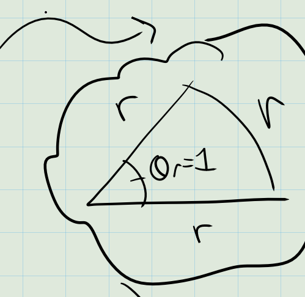

image_2021-04-18-21-51-59

In geometric terms, an angle in radians in the ratio of the arc length $s(\theta, R)$ to the radius $R$, so
$$\begin{align*}
\theta_R = {s(\theta, R) \over R}
.\end{align*}$$

If $\theta$ is an abstract angle, we will say $\theta + k\,\text{rev} \simeq \theta$ for any integer $k\in {\mathbb{Z}}$. Any such angle is said to be **coterminal** to $\theta$.

In radians:
$$\begin{align*}
\theta_R \simeq \theta_R + k\cdot 2\pi && k\in {\mathbb{Z}}
.\end{align*}$$

In degrees:
$$\begin{align*}
\theta_D \simeq \theta_D + k\cdot 360^\circ && k\in {\mathbb{Z}}
.\end{align*}$$

$$\begin{align*}
{\theta \over 1\,\text{rev}} = {\theta_R \over 2\pi\, \text{rad} } = {\theta_D \over 360^\circ}
.\end{align*}$$

$$\begin{align*}
{\theta \over 1\,\text{rev}}
=
{s(R, \theta) \over 2\pi R}
=
{ A(R, \theta) \over \pi R^2 }
.\end{align*}$$

This implies that
$$\begin{align*}
A(R, \theta) &={R^2 \theta \over 2} \\
s(R, \theta) &= R\theta
.\end{align*}$$

## 4.5 Trigonometric Functions as Ratios

There are 6 trigonometric functions defined by the following ratios:

| Function | Domain | Range |
| --- | --- | --- |
| $\sin$ | ${\mathbb{R}}$ | $[-1, 1]$ |
| $\cos$ | ${\mathbb{R}}$ | $[-1, 1]$ |
| $\tan$ | ${\mathbb{R}}\setminus\left\{{\pm {\pi \over 2}, \pm{3\pi \over 2}, \cdots}\right\}$ | ? |
| $\csc$ | ${\mathbb{R}}\setminus\left\{{0, \pm {\pi}, \pm{2\pi}, \cdots}\right\}$ | ? |
| $\sec$ | ${\mathbb{R}}\setminus\left\{{\pm {\pi \over 2}, \pm{3\pi \over 2}, \cdots}\right\}$ | ? |
| $\cot$ | ${\mathbb{R}}\setminus\left\{{0, \pm {\pi}, \pm{2\pi}, \cdots}\right\}$ | ? |

## 4.6 Polar Coordinates

The **unit circle** is defined as
$$\begin{align*}
S^1 \mathrel{\vcenter{:}}=\left\{{ \mathbf{p} = (x, y) \in {\mathbb{R}}^2 {~\mathrel{\Big|}~}d(\mathbf{p}, \mathbf{0}) = 1 }\right\} = \left\{{ (x, y) \in {\mathbb{R}}^2 {~\mathrel{\Big|}~}x^2 + y^2 = 1 }\right\}
,\end{align*}
the set of all points in the plane that are distance exactly 1 from the origin.$$

If a vector $\mathbf{v}$ has at an angle of $\theta$ in radians and has length $R$, the corresponding point $\mathbf{p}$ at the end of $\mathbf{v}$ is given by
$$\begin{align*}
\mathbf{p} = {\left[ {x, y} \right]} = {\left[ {R\cos(\theta), R\sin(\theta)} \right]}
.\end{align*}$$

Conversely, if $(x, y)$ are known, then the corresponding $R$ and $\theta$ are given by
$$\begin{align*}
[R, \theta] = {\left[ { \sqrt{x^2 + y^2}, \arctan\qty{y\over x} } \right]}
.\end{align*}$$

If $R=1$, so $\mathbf{v}$ is on the unit circle $S^1$, then
$$\begin{align*}
[x, y] = [\cos(\theta), \sin(\theta)]
.\end{align*}$$

This is a very important fact! The $x, y$ coordinates on the unit circle *literally* corresponding to cosines and sines of subtended angles will be used frequently.

Cosines are like $x$ coordinates, sines are like $y$ coordinates.

Given $\theta_R = 4\pi/3$, what is the corresponding point on the unit circle $S^1$?

Note that $\sin(\theta), \cos(\theta)$ work for any $\theta$ at all. However, $\cos(\theta) = 0$ sometimes, so $\tan(\theta) \mathrel{\vcenter{:}}=\sin(\theta) / \cos(\theta)$ will on occasion be problematic. Similar story for the other functions.

## 4.7 Special Angles

For reference: the unit circle.

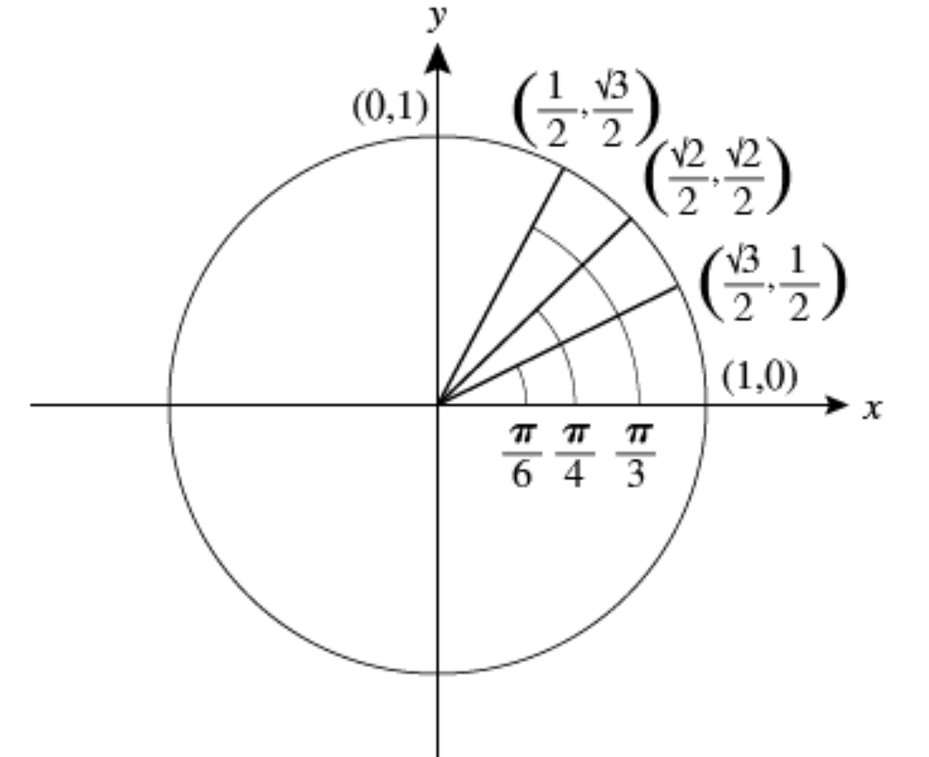

image_2021-04-18-21-06-45

Idea: we want to partition the circle simultaneously

- Into 8 pieces, so we increment by $2\pi/8 = \pi/4$
- Into 12 pieces, so we increment by $2\pi/12 = \pi/6$.

## 4.8 Reference Angles and the Flipping Method

Given a vector at of length $R$ and angle $\theta$, the **reference angle** ${ \theta_{\mathrm{Ref} } }$ is the acute angle in the triangle formed by dropping a perpendicular to the nearest horizontal axis.

Reference angles for each quadrant:
$$\begin{align*}
\text{Quadrant II}: && \theta + { \theta_{\mathrm{Ref} } }= \pi \\
\text{Quadrant III}: && \pi + { \theta_{\mathrm{Ref} } }= \theta \\
\text{Quadrant IV}: && \theta + { \theta_{\mathrm{Ref} } }= 2\pi
.\end{align*}$$

Given $\sin(\theta) = 7/25$, what are the five remaining trigonometric functions of $\theta$?

Method:

1. Draw a picture! Embed $\theta$ into a right triangle.
2. Find the missing side using the Pythagorean theorem.
3. Use definition of trigonometric functions are ratios.

Note that you can not necessarily find the angle $\theta$ here, but we didn’t need it. If we *did* want $\theta$, we would need an inverse function to free the argument:
$$\begin{align*}
\sin(\theta) &= 7/25 \\
\implies \arcsin( \sin(\theta) ) = \arcsin(7/25) \\
\implies \theta = \arcsin(7/25) \\
.\end{align*}$$

## 4.9 Identities Using Pythagoras

$$\begin{align*}
(\sin(\theta))^2 + (\cos(\theta))^2 &= 1 \\
1 + (\cot(\theta))^2 &= (\csc(\theta))^2 \\
(\tan(\theta))^2 + 1 &= (\sec(\theta))^2
.\end{align*}$$

Derive first from Pythagorean theorem in $S^1$. Obtain the second by dividing through by $\qty{\sin(\theta)}^2$. Obtain the third by dividing through by $\qty{\cos(\theta)}^2$.

## 4.10 Even/Odd Properties

Thinking of $\cos(\theta)$ as a function of $\theta$, is it

- Even?
- Odd?
- Neither?

Why do we care? The Fundamental Theorem of Calculus.

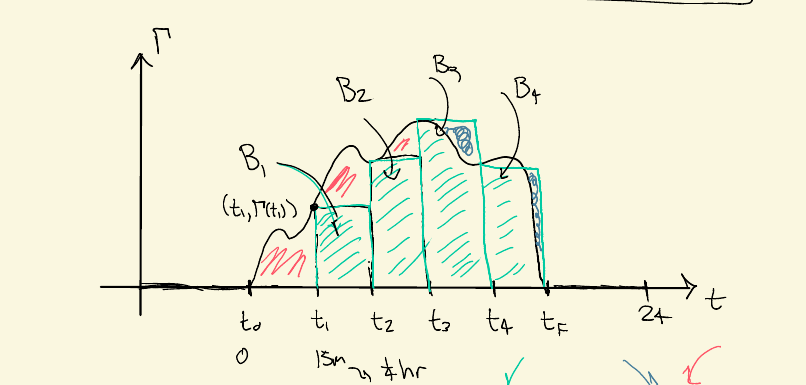

image_2021-04-18-22-39-08

- $f(\theta) \mathrel{\vcenter{:}}=\cos(\theta)$ is an even function.
- $g(\theta) \mathrel{\vcenter{:}}=\sin(\theta)$ is an odd function.

Plot vectors for $\theta, -\theta$ on $S^1$ and flip over the $x{\hbox{-}}$axis.

- $\cos(t), \sec(t)$ are even.
- $\sin(t), \csc(t), \tan(t), \cot(t)$ are odd.

## 4.11 Wave Function

Motivation: let a vector run around the unit circle, where we think of $\theta$ as a time parameter. What are its $x$ and $y$ coordinates? What happens if we plot $x(t)$ in a new $\theta$ plane?

The **standard form** of a wave function is given by
$$\begin{align*}
f(t) \mathrel{\vcenter{:}}= A \cos(\omega (t - \varphi)) + \delta
,\end{align*}$$

where

- $A$ is the **amplitude**,
- $\omega$ is the **frequency**,
- $\phi$ is the **phase shift**, and
- $\delta$ is the **vertical shift**.
- $P \mathrel{\vcenter{:}}= 2\pi / \omega$ is the **period**, so $f(t+kP) = f(t)$ for all $k\in {\mathbb{Z}}$.

Note that this is nothing more than a usual cosine wave, just translated/dilated in the $x$ direction and the $y$ direction.

Don’t memorize equations like $y=\sin(Bt+C)$ and e.g. the phase shift if $\phi = -C/B$. Instead, use a process: always put your equation in standard form, then you can just read off the parameters. For example:
$$\begin{align*}
f(t)
&= \cos(Bt+C) \\
&= \cos( B (t + {C\over B}) ) \\
&= \cos(\omega (t - \phi) ) \\ \\
&\implies B = \omega, \phi = -{C\over B}
.\end{align*}$$

Put the following wave in standard form:
$$\begin{align*}
f(t) \mathrel{\vcenter{:}}= 4\cos(3t+2)
.\end{align*}$$

Put the following wave in standard form:
$$\begin{align*}
f(t) \mathrel{\vcenter{:}}=\alpha \cos(\beta t+\gamma)
.\end{align*}$$

How to plot the graph of a wave equation:

1. Put in standard form.
2. Read off the parameters to build a rectangular box of width $P$ and height $2{\left\lvert {A} \right\rvert}$ about the line $y=\delta$.
3. Break the box into 4 pieces using the key points $t = \phi + {k\over 4}P$ for $k=0,1,2,3,4$.

Plot the following function in the $t$ plane:
$$\begin{align*}
f(t) = 2 \cos\qty{5t - {\pi \over 2} } + 7
.\end{align*}$$

Plot the following:
$$\begin{align*}
f(t) = -2\sin(3t-7)
.\end{align*}$$

Given a picture of a graph of a sine wave,

1. Draw a horizontal line cutting the wave in half. This will be $\delta$.
2. Measure the distance from this midline to a peak. This will be ${\left\lvert {A} \right\rvert}$.
3. Restrict to one full period, starting either at a peak (if you want to match $\cos(t)$) or a zero (if you want to match $\sin(t)$). Pick the period starting as close as possible to the $y{\hbox{-}}$axis.
4. Measure the period $P$ and reverse-engineer it to get $\omega$: $P = 2\pi/\omega \implies \omega = 2\pi/P$.
5. Measure the distance from the starting point to the $y{\hbox{-}}$axis: this is $\phi$.

Determine the equation of the following wave function:

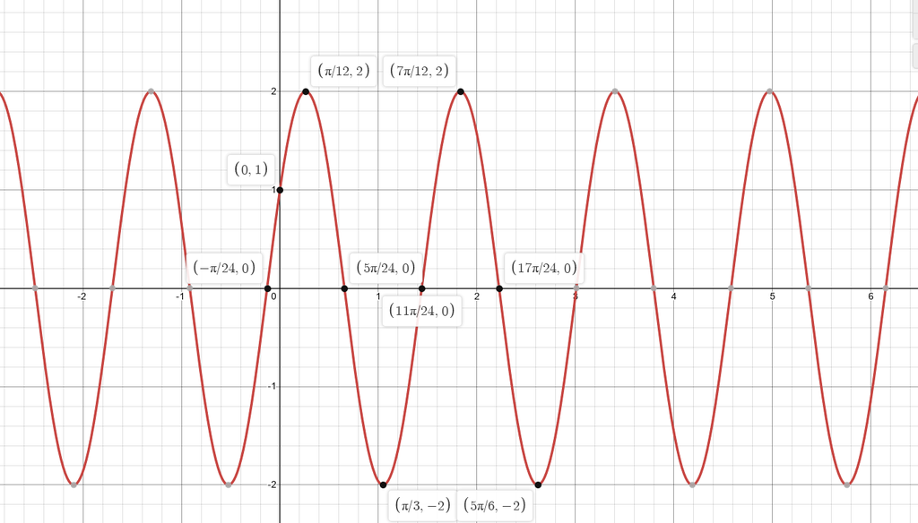

image_2021-04-18-20-51-34

$$\begin{align*}
f(t) = 2\sin\qty{4t + {\pi \over 6} }
.\end{align*}$$

Note that we can graph other trigonometric functions: they get pretty wild though.

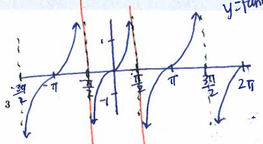

Tangent

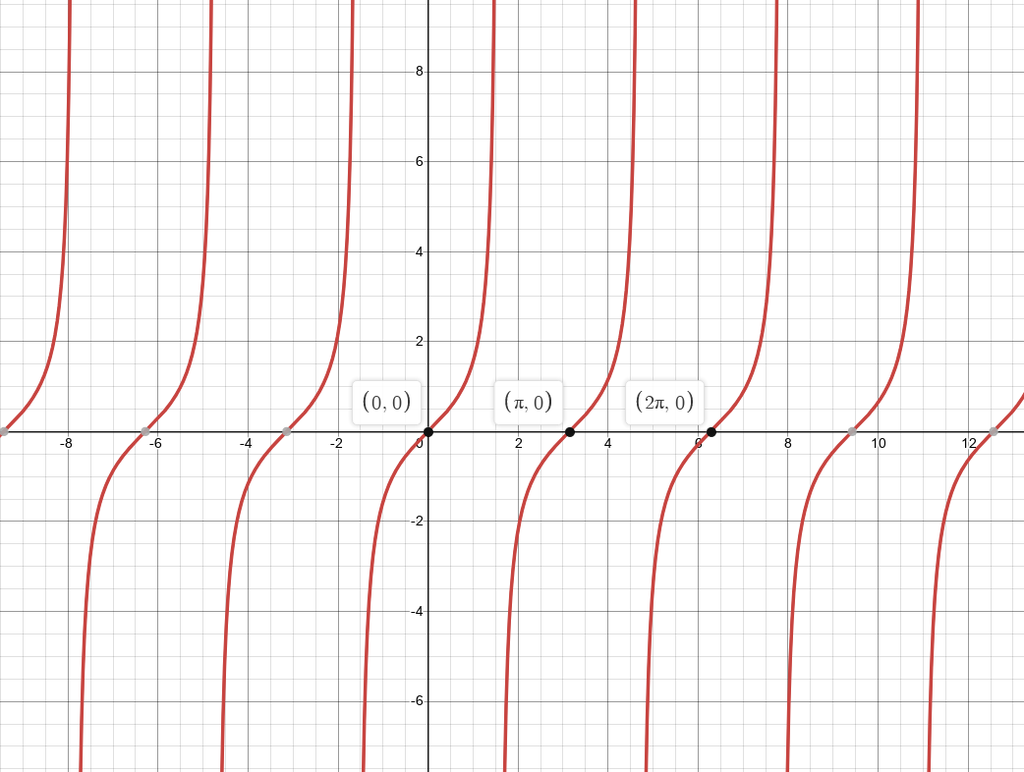

## 4.12 Simplifying Identities

The goal: reduce a complicated mess of trigonometric functions to something as simple as possible. We’ll use a **boxing-up method**.

On verifying identities: if you want to show $f(\theta) = g(\theta)$, start at one and arrive at the other:
$$\begin{align*}
f(\theta) &= \text{simplify } f \\
&= \cdots \\
&= \cdots \\
&= \cdots \\
&= g(\theta) \\
.\end{align*}$$

If you end up with something like $1=1$ or $0=0$, this is hinting at a problem with your logic.

Simplify the following:
$$\begin{align*}
F(\theta) \mathrel{\vcenter{:}}=\qty{ \sin(\theta) \cos(\theta) \over \cot(\theta)} \cos(\theta)\csc(\theta)
.\end{align*}$$

As an alternative, you can use the **transitivity of equality**: show that $f(\theta) = h(\theta)$ for some totally different function $h$, and then show $g(\theta) = h(\theta)$ as well.

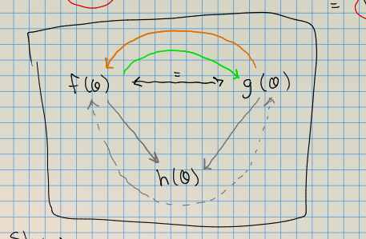

image_2021-04-18-21-58-52

Show the following identity:
$$\begin{align*}
{\sin(-\theta) + \csc(\theta)} = \cot(\theta) \cos(\theta)
\end{align*}
by showing both sides are separately equal to \(h(\theta) \mathrel{\vcenter{:}}=\csc(\theta) - \sin(\theta)\).$$

## 4.13 Inverse Functions

### 4.13.1 Motivation

Motivation: we want a way to solve equations where the unknown $\theta$ is stuck in the argument of a trigonometric function. For example, for $\sin: {\mathbb{R}}_A \to {\mathbb{R}}_B$, this would be some function $f: {\mathbb{R}}_B \to {\mathbb{R}}_A$ such that
$$\begin{align*}
f(\sin(\theta)) &= \operatorname{id}(\theta) = \theta \\
\sin(f(y)) &= \operatorname{id}(y) = y
.\end{align*}$$

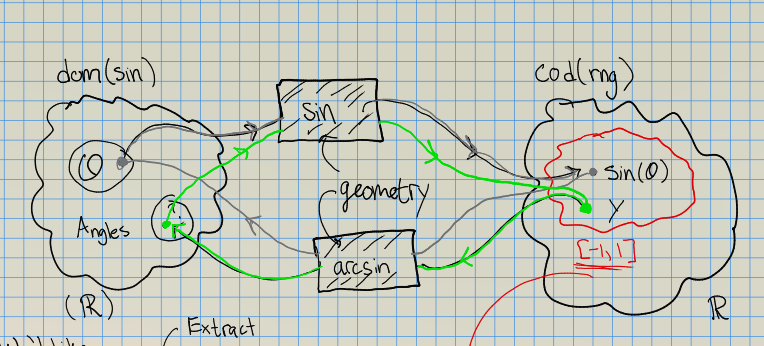

Input-Output perspective: important!

Note that we only ever have to define $f$ on $\mathop{\mathrm{range}}(\sin)$, since we’re only ever sending outputs of $f$ in as the inputs of $\sin$. So we need $\mathop{\mathrm{range}}(\sin) \subset \operatorname{dom}(f)$, noting that $\mathop{\mathrm{range}}(\sin) = [-1, 1]$:

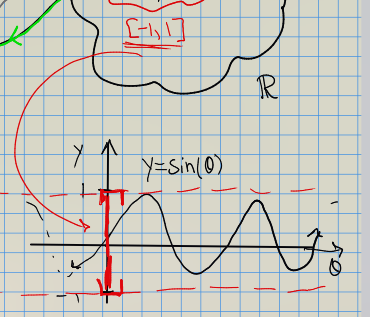

Similarly, we need $\mathop{\mathrm{range}}(f) \subset \operatorname{dom}(\sin)$.

### 4.13.2 Using Triangles

Optimistically imagine that we had some such inverse function. Then we could evaluate some expressions without even knowing anything else about it. The trick:
$$\begin{align*}
\theta &= \arccos(p/q) \\
\implies \cos(\theta) &= \cos(\arccos(p/q)) \\
\implies \cos(\theta) &= p/q
.\end{align*}
Now embed this in a triangle. We can’t solve for \(\theta\), but we can solve for other trigonometric functions.$$

$$\begin{align*}
\cos\qty{ \arccos\qty{ \sqrt 5 \over 5 } } &= {\sqrt 5 \over 5} \\
\arccos\qty{ \cos \qty{ \sqrt 5 \over 5 } } &= {\sqrt 5 \over 5}
.\end{align*}$$

$$\begin{align*}
\tan\qty{ \arcsin\qty{ p \over q } } = {p \over \sqrt{q^2 - p^2} }
.\end{align*}$$

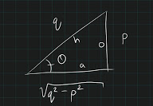

image_2021-04-22-22-14-13

Compute $\arcsin(3/5)$.

This is equal to $\sin^{-1}(3/5)$, which is *not* equal to ${1\over \sin(3/5)}$! One way to remember this is that we have another name for reciprocals, here $\csc(3/5)$.

$$\begin{align*}
\theta &= \arcsin(3/5) \\
\implies \sin(\theta) &= (3/5) && \text{roughly by injectivity} \\
\implies &= \cdots ?
.\end{align*}
We are out of luck, since this isn’t a special angle. So we can’t find a numerical value of \(\theta\). We can find other trig functions of \(\theta\) though:$$

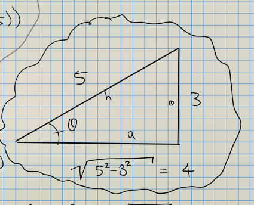

image_2021-04-18-22-30-09

So for example, $\cos(\arcsin(3/5)) = 4/5$.

Most inverse trigonometric functions can *not* be exactly solved! We’ll have to approximate by calculator if we want the actual angle. If we just want *other* trigonometric functions though, we can always embed in a triangle.

### 4.13.3 Defining Inverses

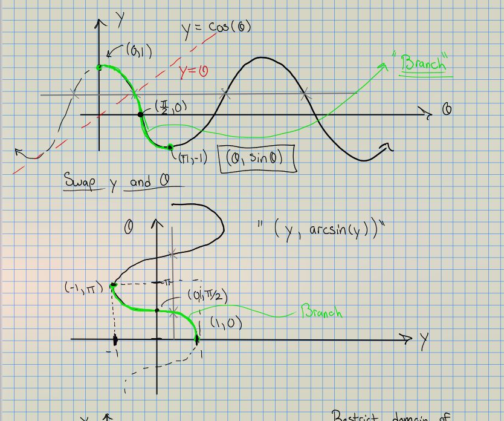

image_2021-04-18-22-32-36

Note that the latter is a function (vertical line test) iff the former is injective (horizontal line test). So we take the largest branch where the inverse is a function:

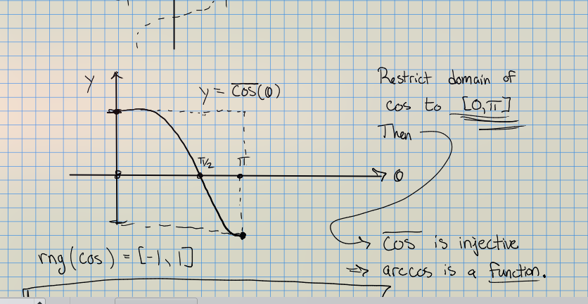

image_2021-04-18-22-33-27

Back on our original graph, this looks like the following:

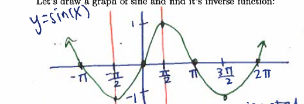

image_2021-04-18-20-53-25

Restricting, we get

- $\operatorname{dom}(\arccos) \mathrel{\vcenter{:}}=\mathop{\mathrm{range}}({ \color{green} \cos} ) = [-1, 1]$.
- $\mathop{\mathrm{range}}(\arccos) \mathrel{\vcenter{:}}=\operatorname{dom}( {\color{green} \cos} ) = [0, \pi]$.

A similar analysis works for $\sin(\theta)$:

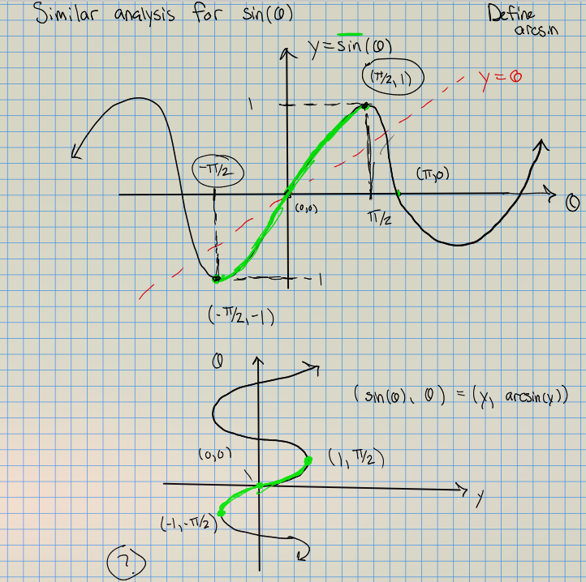

image_2021-04-18-22-34-21

Restricting, we get

- $\operatorname{dom}(\arcsin) \mathrel{\vcenter{:}}=\mathop{\mathrm{range}}({ \color{green} \sin} ) = [-1, 1]$.
- $\mathop{\mathrm{range}}(\arcsin) \mathrel{\vcenter{:}}=\operatorname{dom}( {\color{green} \sin }) = [-\pi/2, \pi/2]$.

This gives us a new tool to solve equations:
$$\begin{align*}
\vdots &= \vdots \\
\implies \cos(x) &= b \\
\implies \arccos(\cos(x)) &= \arccos(b) \\
\implies x &= \arccos(b)
,\end{align*}
but only if we know this makes sense based on domain/range issues.$$

Restrict domains in the following ways:

- $\sin$: $[-\pi/2, \pi/2]$
- $\cos: [0, \pi]$
- $\tan: [-\pi/2, \pi/2]$

| Function | Domain | Range |
| --- | --- | --- |
| $\arcsin$ | $[-1, 1]$ | $[-\pi/2, \pi /2]$ |
| $\arccos$ | $[-1, 1]$ | $[0, \pi]$ |
| $\arctan$ | ${\mathbb{R}}$ | $(-\pi/2, \pi/2)$ |
| $\operatorname{arccsc}$ | ${\mathbb{R}}\setminus\left\{{0, \pm {\pi}, \pm{2\pi}, \cdots}\right\}$ | $[-\pi/2, \pi/2]\setminus\left\{{0}\right\}$ |
| $\operatorname{arcsec}$ | ${\mathbb{R}}\setminus\left\{{\pm {\pi \over 2}, \pm{3\pi \over 2}, \cdots}\right\}$ | $[0, \pi]\setminus\left\{{\pi/2}\right\}$ |
| $\operatorname{arccot}$ | ${\mathbb{R}}$ | $(0, \pi)$ |

There is an easy way to remember this:

- Cosines are $x{\hbox{-}}$values, pick the upper (or lower) half of the circle to make them unique.
- Sines are $y{\hbox{-}}$values, pick the right (or left) half of the circle to make them unique.

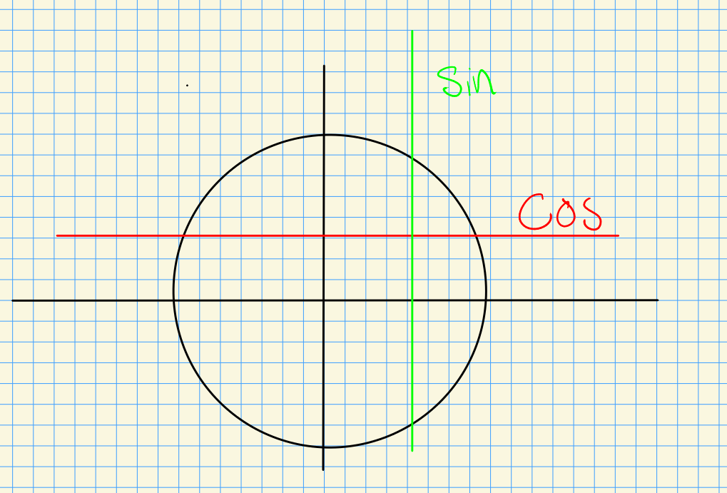

image_2021-04-22-22-00-04

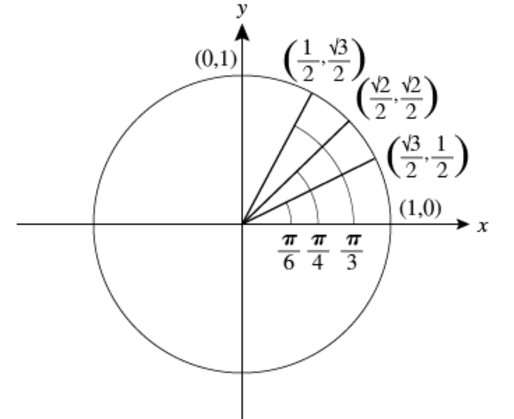

Unit Circle

We have some exact values.

Sines should be in QI or QIV:

- $\arcsin(1/2) = \pi/6$
- $\arcsin(\sqrt{3}/2) = \pi/3$
- $\arcsin(-1/2) = -\pi/6$

Cosines should be in QI or QII:

- $\arccos(\sqrt{3}/2) = \pi/6$
- $\arccos(-\sqrt{2}/2) = 3\pi/4$
- $\arccos(1/2) = \pi/3$

Tangents should be in QI or QIV:

- $\arctan(\sqrt{3}/3) = \pi/6$
- $\arctan(0) = 0$
- $\arctan(1) = \pi/4$

Note that if $f, g$ are an inverse pair, we have
$$\begin{align*}
f\circ g = \operatorname{id}\quad\iff\quad f(g(x)) = x,\quad g(f(x)) = x
.\end{align*}
However, we have to be careful with domains for trigonometric functions:$$

## 4.14 Double/Half-Angle Identities

Sometimes we are interested in **superposition** of waves, see [Desmos](https://www.desmos.com/calculator/rhliflgwmv) for an example. Mathematically this is modeled by adding wave functions together. Similarly, we are sometimes interested in **modulating** or **enveloping** waves, which is modeled by multiplying a wave with another function: see [Desmos](https://www.desmos.com/calculator/wjgcl2xfbb).

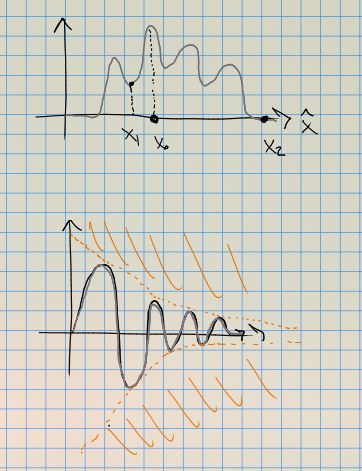

image_2021-04-18-22-06-08

We can sometimes rewrite these as a *single* wave with a phase shift.

Sines are friendly and cosines are clique-y!

Why do we care? We had 16 special angles, this gives a lot more. For example,
$$\begin{align*}
\cos(\pi/12)
=
\cos(\pi/3 - \pi/4) = \cdots \text{ plug in}
.\end{align*}
By allowing increments of \(\pi/12\), we have 24 total angles.$$

Starting from the following:
$$\begin{align*}
\cos(2\theta)
&= \cos^2(\theta) - \sin^2(\theta) \\
&= \cos^2(\theta) - \qty{1 - \cos^2(\theta) } \\
&= 2\cos^2(\theta) -1 && \text{using } s^2 + c^2 = 1
,\end{align*}
one can solve for
\begin{align*}
\cos^2(\theta) = {1\over 2}\qty{1 + \cos(2\theta) }
.\end{align*}$$

Similarly
$$\begin{align*}
\cos(2\theta)
&= \cos^2(\theta) - \sin^2(\theta) \\
&= \qty{1 - \sin^2(\theta) } - \sin^2(\theta) \\
&= 1-2\sin^2(\theta) && \text{using } s^2 + c^2 = 1
,\end{align*}
solving yields
\begin{align*}
\sin^2(\theta) = {1\over 2} (1 - \cos(2\theta) )
.\end{align*}$$

These are very important in Calculus! This gives us a way to reduce the exponents on expressions like $\sin^n(\theta)$.

## 4.15 Bonus: Complex Exponentials

We spent one entire unit studying the function $f(x) = e^x$, and another studying the functions $g(x) = \cos(x), h(x) = \sin(x)$. They seem completely unrelated, but miraculously they are both just shadows of of unifying concept.

Components of vectors: every $\mathbf{v}\in {\mathbb{R}}^2$ breaks up as the sum of two vectors, i.e. $\mathbf{v} = \mathbf{v}_x + \mathbf{v}_y$. In coordinates, if $\mathbf{v} = (a, b)$, we have $\mathbf{v}_x = (a, 0)$ and $\mathbf{v}_y = (0, b)$. Alternatively, we can drop the ordered pair notation and write $\mathbf{v} = a \widehat{\mathbf{x}} + b \widehat{\mathbf{y}}$.

We’ve worked with the *Cartesian plane* all semester. One powerful tool is replacing this with the *complex* plane. We formally define a new symbol $i$ and replace the $\widehat{ \mathbf{y} }$ direction with the $i$ direction – this amounts to replacing ordered pairs $(a, b) \mathrel{\vcenter{:}}= a \widehat{ \mathbf{x} } + b\widehat{ \mathbf{y} }$ by a single number $a + ib$.

Complex numbers can be added:
$$\begin{align*}
(a + bi) + (c + di) = (a + c) + (b + d)i
.\end{align*}
This is perhaps easier to understand in the ordered pair notation: you just add the components in each component:
\begin{align*}
[a, b] + [c, d] = [a + c, b + d]
.\end{align*}$$

Complex numbers can be multiplied:
$$\begin{align*}
(a +bi)(c+di)
&= a(c+di) + bi(c+di) \\
&= ac + adi + bci + bdi^2 \\
&= (ac - bd) + (ad + bc)i
.\end{align*}
This is harder to see in the ordered pair notation.$$

We can compare complex numbers: they are equal iff their components are equal:
$$\begin{align*}
a + bi = c+di \iff a=c \text{ and } b = d
,\end{align*}
or in ordered pair notation,
\begin{align*}
[a, b] = [c, d] \iff a = c \text{ and } b = d
.\end{align*}$$

The symbol $i$ happens to have another algebraic property. Consider the family of equations $f(x, t) = x^2 + t$, and think about finding the roots. Finding a root is solving $f(x, t) = 0$, which is the exact same thing as finding the intersection points with the graph of $g(x) = 0$. Taking $t=0$ yields $f(x) = x^2$, which has a root at zero. Taking $t<0$ yields two roots. However, taking $t>0$ yields no roots – at least not in ${\mathbb{R}}$. As it turns out, the function $f_1(x) = x^2 + 1$ and $g(x) = 0$ *do* intersect in some other, bigger space, and we’re only seeing a shadow of this! In other words, $x^2+1=0$ didn’t have solutions in ${\mathbb{R}}$, but *will* have a solution in ${\mathbb{C}}$.

The following is the main link between exponentials and waves:

$$\begin{align*}
e^{i\theta} = \cos(\theta) + i\sin(\theta)
.\end{align*}$$

Really, this is just polar coordinates on the unit circle: if we go back to ordered pair notation, this is just giving a point $(\cos(\theta), \sin(\theta)) \in S^1$. So the *complex number* $e^{i\theta}$ is also a *vector* pointing at an angle $\theta$ from the origin and landing on the unit circle.

$$\begin{align*}
e^{i\pi} = -1
.\end{align*}$$

This is remarkable! It relates some of the most fundamental constant numbers in mathematics:

- $e = 2.718\ldots$
- $\pi = 3.14159\ldots$
- $-1$

Proof: just plug $\pi$ into Euler’s equation. Geometric interpretation: $\pi$ radians is directly to the left.

An application: proving the angle sum formulas algebraically. We start by considering the angle $\alpha + \beta$. On one hand, Euler’s formula says
$$\begin{align*}
e^{i( \alpha + \beta) } = \cos(\alpha + \beta) + i\sin(\alpha + \beta)
= [\cos(\alpha + \beta), \sin(\alpha + \beta)]
.\end{align*}$$

On the other hand, we can use properties of exponentials first and expand:
$$\begin{align*}
e^{i(\alpha + \beta)}
&= e^{i\alpha} e^{i\beta} \\
&= \qty{ \cos(\alpha) + i\sin(\alpha)} \cdot \qty{ \cos(\beta) + i\sin(\beta) } \\
&=
\cos(\alpha)
\qty{ \cos(\beta) + i\sin(\beta) }
+
i\sin(\alpha)
\qty{ \cos(\beta) + i\sin(\beta) }
\\
&=
\cos(\alpha)\cos(\beta) + i \cos(\alpha)\sin(\beta)
+
i\sin(\alpha)\cos(\beta) + i^2 \sin(\alpha)\sin(\beta)
\\
&= \qty{ \cos(\alpha)\cos( \beta) - \sin(\alpha)\sin(\beta) }
+
i
\qty{\cos(\alpha) \sin(\beta) + \sin(\alpha)\cos(\beta) } \\
&=
\left[ \cos(\alpha)\cos( \beta) - \sin(\alpha)\sin(\beta),\quad
\cos(\alpha) \sin(\beta) + \sin(\alpha)\cos(\beta)
\right]
.\end{align*}$$

Now we just equate components:

$$\begin{align*}
[\cos(\alpha + \beta), \sin(\alpha + \beta)]
&= \left[ \cos(\alpha)\cos( \beta) - \sin(\alpha)\sin(\beta),\quad
\cos(\alpha) \sin(\beta) + \sin(\alpha)\cos(\beta)
\right] \\ \\
\implies \cos(\alpha + \beta) &= \cos(\alpha)\cos(\beta) - \sin(\alpha)\sin(\beta) \\
\implies \sin(\alpha + \beta) &= \cos(\alpha)\sin(\beta) + \sin(\alpha)\cos(\beta)
.\end{align*}$$

The analogy goes farther: polar coordinates are essentially just a shadow of complex numbers. Since $e^{i\theta} \in S^1$, we can scale by a radius $r$ to write $z = re^{i\theta}$ and get any point in the plane. If we just draw a vector $\mathbf{v}[r\cos(\theta), r\sin(\theta)]$, note that Euler’s formula gives us a way to get a complex number $z$ that corresponds to it:
$$\begin{align*}
z \mathrel{\vcenter{:}}= re^{i\theta} = r(\cos(\theta) + i\sin(\theta)) = r\cos(\theta) + i\cdot r\sin(\theta) = [r\cos(\theta), r\sin(\theta)] = \mathbf{v}
.\end{align*}$$

Results like these are at the heart of mathematics: having a bunch of equations, seeing patterns, and trying to find some common, unifying, and hopefully simpler structure that underlies all of it. An example you’ll see in Calculus: all of the graphs we’ve been looking at in this class are “shadows” of intersecting shapes in some higher dimensional space!

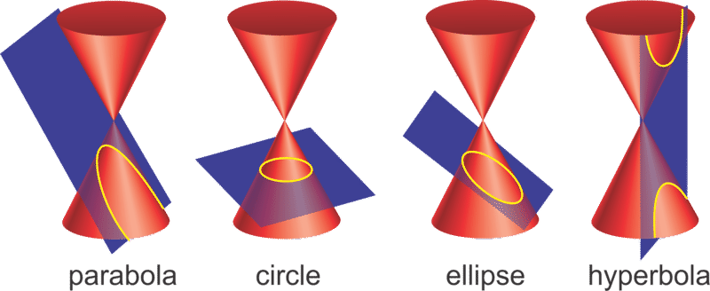

Conic Sections

# 5 Bibliography